# Notes/A11

Hi! I’m gonna do my notes like this because I (really really) like working in RMarkdown and I feel like this will be an efficient way to turn them in while separating code + notes.

# Notes

- Multi-level modeling is useful for ecology/biology due to multiple groupings.
- Color palette function is in base R (which is nice)
- Alpha value is two extra digits at end of HEX code!!!!!!

```r
cols <- palette.colors(10, "Dark2")
cols.t <- paste(cols, "50", sep = "") # pro tip ... alpha is transparency and tacked onto the end of the color!
library(lme4)
```

- Linear regression formula is $Y=\alpha+\beta*X+\epsilon$, where the predicted value (Y) is the intercept ($\alpha$) + the estimated slope ($\beta$) times the X-value, plus the residual (or error; $\epsilon$)
- If you add up all the residuals, the distribution should be normal, and the variance is $\sigma^{2}$.
  - SD is $\sigma$

## Making up fake data

```r
N <- 1000   # individual number (how many measurements have been made)
X <- rnorm(N, 4, 1) # generating the data
summary(X)
```

```
##    Min. 1st Qu.  Median    Mean 3rd Qu.    Max.
##   1.291   3.311   3.984   3.993   4.664   7.163
```

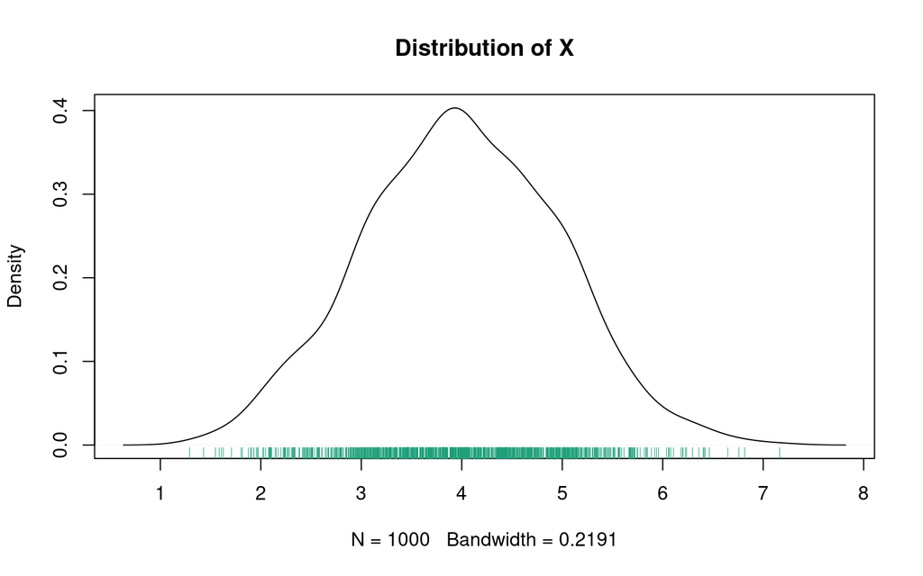

```r
plot(density(X), main = "Distribution of X")
rug(X, col = cols[1])
```

- Rug plot helps visualize density of data
- Okay, so we’re trying to figure out how X and Y are related in this kind of modeling, so here is a fake relationship we will use to calculate Y from our generated X vals

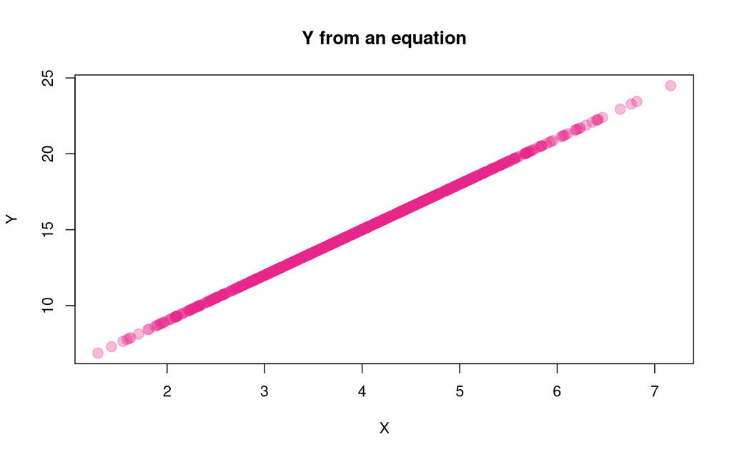

```r
alpha <- 3
beta  <- 3
Y <- alpha + beta * X
plot(X, Y, col = cols.t[4], pch = 19, cex = 1.5, main = "Y from an equation")
```

- Looked too perfect because there is no uncertainty
- Generating data by distribution makes it easier to add variance

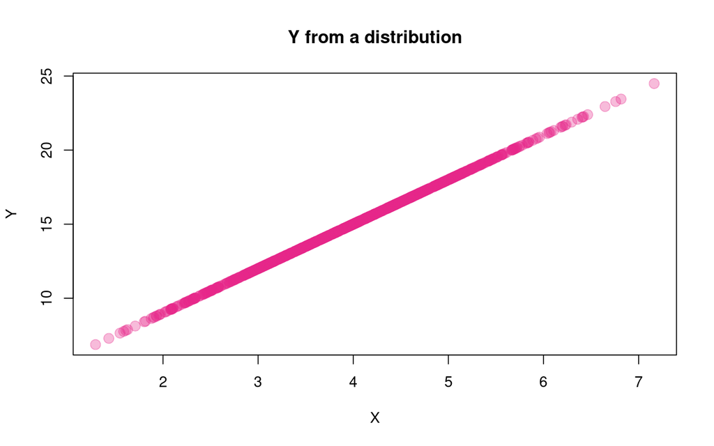

```r
Y <- rnorm(N, alpha + beta * X, 0)
plot(X, Y, col = cols.t[4], pch = 19, cex = 1.5, main = "Y from a distribution")
```

- Now adding sigma to add variance, performing linear regression, and plotting this line on the graph; then performing summary to see if our calculated model fits

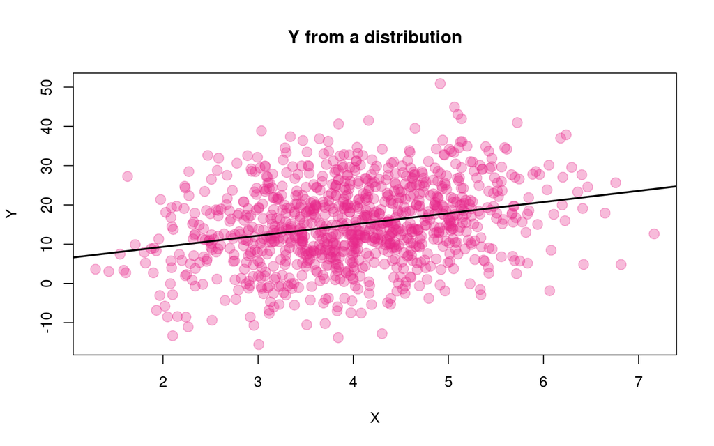

```r
sigma <- 10 # make sigma
Y <- rnorm(N, alpha + beta * X, sigma)
plot(X, Y, col = cols.t[4], pch = 19, cex = 1.5, main = "Y from a distribution")
lin.mod <- lm(Y ~ X) # fit the model
abline(lin.mod, col = "black", lwd = 2)
```

```r
print(summary(lin.mod))
```

```
##
## Call:
## lm(formula = Y ~ X)
##
## Residuals:
##     Min      1Q  Median      3Q     Max
## -28.693  -6.221  -0.462   6.855  33.267
##
## Coefficients:
##             Estimate Std. Error t value Pr(>|t|)
## (Intercept)   3.6138     1.3226   2.732   0.0064 **
## X             2.8531     0.3219   8.864   <2e-16 ***
## ---
## Signif. codes:  0 '***' 0.001 '**' 0.01 '*' 0.05 '.' 0.1 ' ' 1
##
## Residual standard error: 9.862 on 998 degrees of freedom
## Multiple R-squared:  0.07298,    Adjusted R-squared:  0.07205
## F-statistic: 78.57 on 1 and 998 DF,  p-value: < 2.2e-16
```

```r
lm(formula = Y ~ X)
```

```
##
## Call:
## lm(formula = Y ~ X)
##
## Coefficients:
## (Intercept)            X
##       3.614        2.853
```

- Note difference in significance when changing sigma/increasing uncertainty
- As noise gets higher, it is harder to predict the relationship out of the cloud
- We can incorporate multiple variables into this to see what exactly is affecting Y
- Adjusted R$^{2}$ penalizes for extra parameters, especially ones that don’t do much to explain extra variables

## Multi-Level Modeling

- Some noise can obscure the trend in data; some noise can be really valuable information that tells us more about the system
- We’re going to edit our data so that there are groups (that may have different alphas and betas) within the population
  - Basically, we have to think of there being two levels of variance
- Sigma group intercept is just the overall variance between the groups

```r
J <- 10
ID <- rep(seq(J), length = N)
sigma_group_int <- 3
set.seed(15)
alpha_j <- rnorm(J, alpha, sigma_group_int)
sd(alpha_j)
```

```
## [1] 2.863328
```

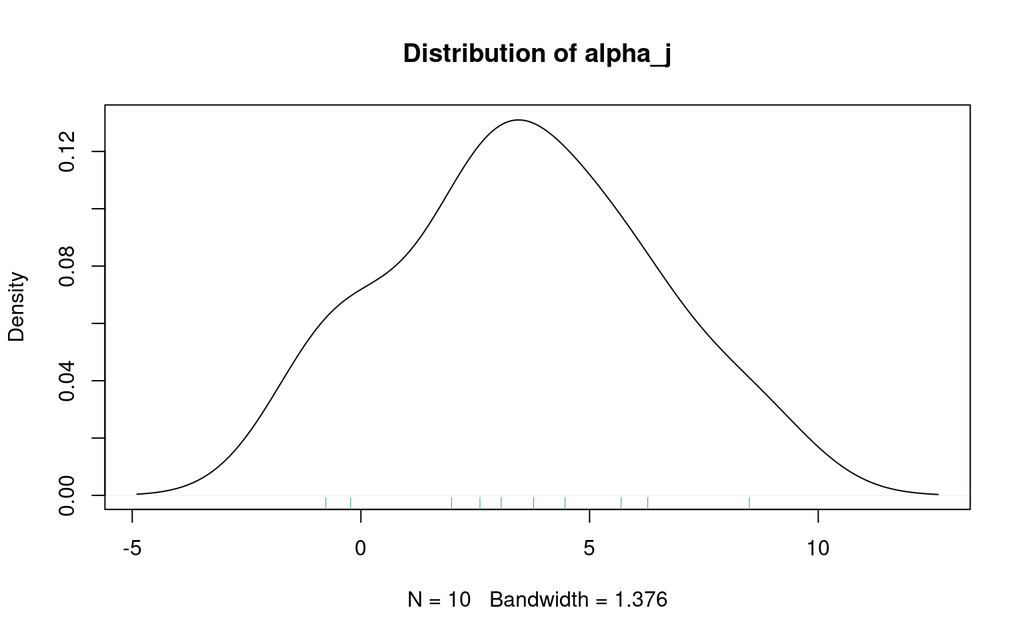

```r
plot(density(alpha_j), main = "Distribution of alpha_j")
rug(alpha_j, col=cols[1])
```

- Since we are sampling 10 repeatedly, it’s gonna give us weird bumps/ slightly not normal distribution

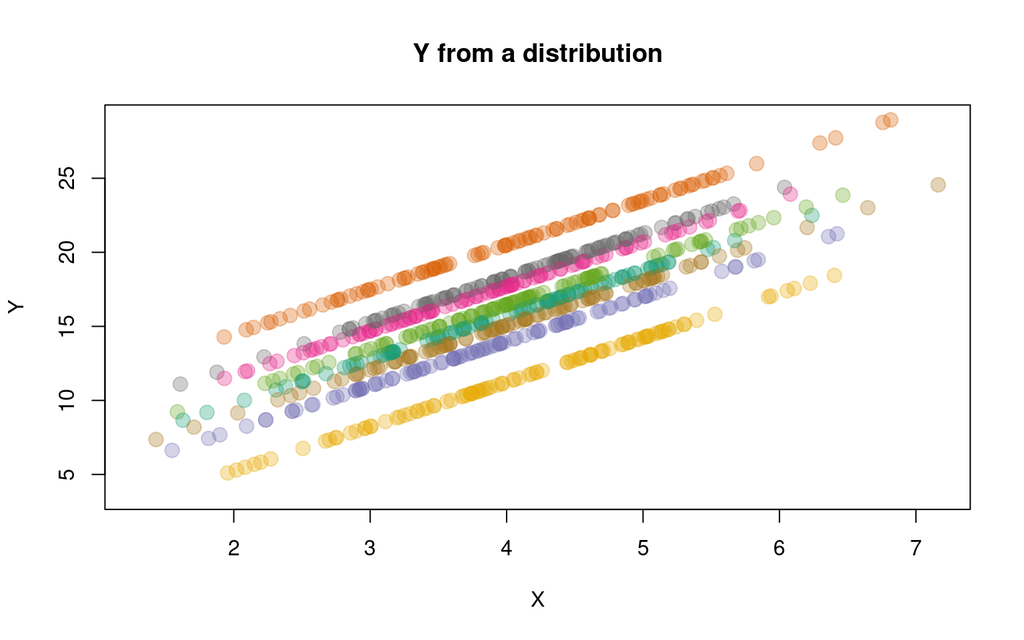

```r
Y <- rnorm(N, alpha_j[ID] + beta * X, 0)

plot(X, Y, col = cols.t[ID], pch = 19, cex = 1.5, main = "Y from a distribution")
```

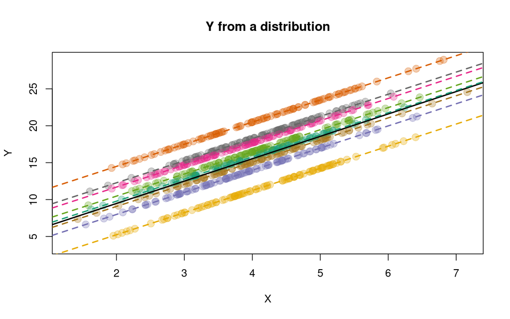

```r
plot(X, Y, col = cols.t[ID], pch = 19, cex = 1.5, main = "Y from a distribution")
lin.mod.group <- lm(Y ~ X)
abline(lin.mod.group, col = "black", lwd = 2)
for(j in 1:J) {

  X.1 <- subset(X, ID == j)
  Y.1 <- subset(Y, ID == j)

  lin.mod.group <- lm(Y.1 ~ X.1)
  abline(lin.mod.group, col = cols[j], lwd = 2, lty = 2)
}
```

- So now we have varying intercepts!!!
- Now going to add a sigma in and plot it

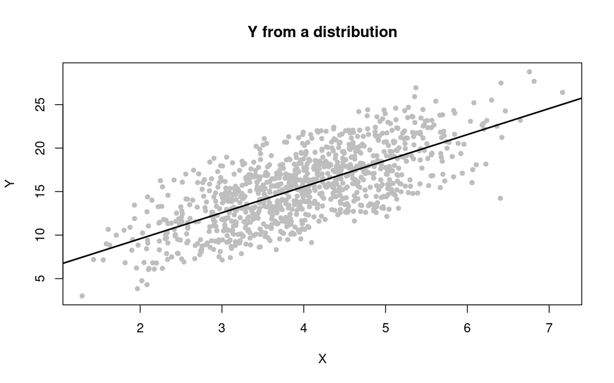

```r
sigma <- 1
Y <- rnorm(N, alpha_j[ID] + beta * X, sigma)
plot(X, Y, col = 'gray', pch = 19, cex = 0.75, main = "Y from a distribution")
lin.mod.group <- lm(Y ~ X)
abline(lin.mod.group, col = "black", lwd = 2)
```

```r
print(summary(lin.mod.group))
```

```
##
## Call:
## lm(formula = Y ~ X)
##
## Residuals:
##     Min      1Q  Median      3Q     Max
## -8.5299 -2.1367  0.0105  2.0435  7.2679
##
## Coefficients:
##             Estimate Std. Error t value Pr(>|t|)
## (Intercept)  3.59910    0.38784    9.28   <2e-16 ***
## X            2.99281    0.09439   31.71   <2e-16 ***
## ---
## Signif. codes:  0 '***' 0.001 '**' 0.01 '*' 0.05 '.' 0.1 ' ' 1
##
## Residual standard error: 2.892 on 998 degrees of freedom
## Multiple R-squared:  0.5018, Adjusted R-squared:  0.5013
## F-statistic:  1005 on 1 and 998 DF,  p-value: < 2.2e-16
```

- Now how do we separate the groups out and do LM for each of them plus an overall lm? LMER
- For LMER, putting things in the parantheses means evaluate for each group. Outside parantheses is for the population

```r
plot(X, Y, col = cols.t[ID], pch = 19, cex = 0.75, main = "Y from a distribution")
lme.mod <- lmer(Y ~ 1 + X + (1 | ID))
print(summary(lme.mod))
```

```
## Linear mixed model fit by REML ['lmerMod']
## Formula: Y ~ 1 + X + (1 | ID)
##
## REML criterion at convergence: 2950.6
##
## Scaled residuals:
##     Min      1Q  Median      3Q     Max
## -4.1461 -0.6347  0.0434  0.6774  3.1522
##
## Random effects:
##  Groups   Name        Variance Std.Dev.
##  ID       (Intercept) 8.115    2.849
##  Residual             1.046    1.023
## Number of obs: 1000, groups:  ID, 10
##
## Fixed effects:
##             Estimate Std. Error t value
## (Intercept)  3.74267    0.91134   4.107
## X            2.95686    0.03356  88.097
##
## Correlation of Fixed Effects:
##   (Intr)
## X -0.147
```

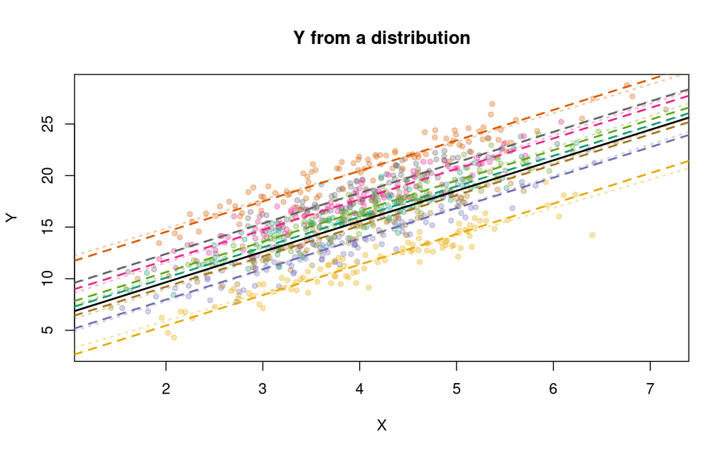

```r
fix.ef <- as.numeric(fixef(lme.mod))

abline(a = fix.ef[1], b = fix.ef[2], col = "black", lwd = 2)
ran.ef <- as.numeric(unlist(ranef(lme.mod)))
for(j in 1:J) {
abline(a = ran.ef[j] + fix.ef[1], b = fix.ef[2], col = cols[j], lwd = 2, lty = 2)
  X.1 <- subset(X, ID == j)
  Y.1 <- subset(Y, ID == j)

  lin.mod.group <- lm(Y.1 ~ X.1)
  abline(lin.mod.group, col = cols.t[j], lwd = 2, lty = 3)

}
```

- Remember to not include outliers in this analysis because the computer will apply the wrong sort of models to it (shrubs in a canopy tree analysis)
- Saves all parts of the output (str) (useful for Horseshoe crab evolution plot if I run them this way)
- Sorry if the notes get spotty here, things got a little over my head!!
- Random effect is difference in groups for intersects
- Arm package might be useful for later horseshoe crab stuff
- Data Analysis… by Gelman and Hill might be useful reading
- Pool model = everyone together, unpooled is when you start to separate groups out

*Side note: I am thinking about using genetic analysis in the future so this might be really helpful in the future; I just don’t quite understand yet!!

```r
cbind(ran.ef + alpha, alpha_j)
```

```
##                     alpha_j
##  [1,]  3.4286923  3.7764686
##  [2,]  7.8816260  8.4933621
##  [3,]  1.3150291  1.9811443
##  [4,]  5.1211813  5.6915945
##  [5,]  3.9754572  4.4640489
##  [6,] -1.2029773 -0.7661575
##  [7,]  2.5603478  3.0683646
##  [8,]  5.7463455  6.2723196
##  [9,]  1.9277978  2.6036327
## [10,] -0.7534998 -0.2250038
```

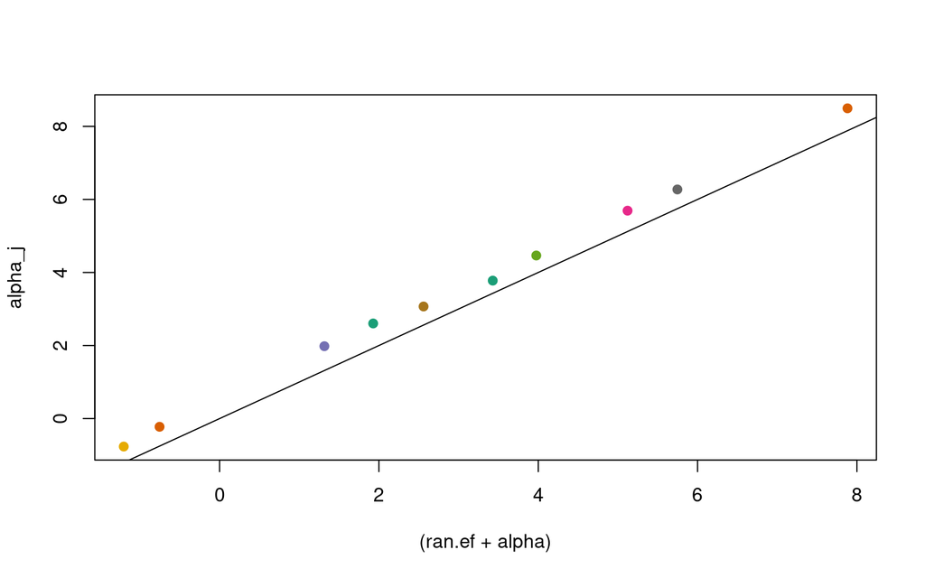

```r
plot((ran.ef + alpha), alpha_j, col = cols, pch = 19)
abline(b = 1, a = 0)
```

```r
fixef(lme.mod)
```

```
## (Intercept)           X
##    3.742673    2.956856
```